```r
library("TCGAbiolinks")
library("survival")
library("survminer")
```

1- Load the data

```r
tcga_data = readRDS(file = "tcga_data.RDS")
```

2- Extract clinical data

```r
# extract clinical data
clinical = tcga_data@colData

dim(clinical)
```

```
## [1] 424  64
```

3- Print column names

```r
colnames(clinical)
```

```
##  [1] "barcode"                     "patient"
##  [3] "sample"                      "shortLetterCode"
##  [5] "definition"                  "sample_submitter_id"
##  [7] "is_ffpe"                     "tissue_type"
##  [9] "state"                       "submitter_id"
## [11] "sample_id"                   "sample_type_id"
## [13] "oct_embedded"                "sample_type"
## [15] "initial_weight"              "pathology_report_uuid"
## [17] "days_to_collection"          "classification_of_tumor"
## [19] "days_to_last_follow_up"      "last_known_disease_status"
## [21] "ajcc_pathologic_n"           "primary_diagnosis"
## [23] "ajcc_pathologic_t"           "age_at_diagnosis"
## [25] "ajcc_pathologic_m"           "year_of_diagnosis"
## [27] "icd_10_code"                 "tumor_grade"
## [29] "prior_malignancy"            "ajcc_staging_system_edition"
```

[output cut: 17 more lines]

4- Need to extract the race variable, and a few more besides

```r
# we are only interested in the "Primary solid Tumor" cases for survival
clin_df = clinical[clinical$definition == "Primary solid Tumor",
                    c("patient",
                      "vital_status",
                      "days_to_death",
                      "days_to_last_follow_up",
                      "race")]
```

5- we need to change part of this information in a way that is acceptable to the methods from the `survival` package we are using:

```r
# create a new boolean variable that has TRUE for dead patients
# and FALSE for live patients
clin_df$deceased = clin_df$vital_status == "Dead"

# create an "overall survival" variable that is equal to days_to_death
# for dead patients, and to days_to_last_follow_up for patients who
# are still alive
clin_df$overall_survival = ifelse(clin_df$deceased,
                                   clin_df$days_to_death,
                                   clin_df$days_to_last_follow_up)

# show first 10 samples
head(clin_df)
```

```
## DataFrame with 6 rows and 7 columns
##                                   patient vital_status days_to_death
##                               <character>  <character>     <integer>
## TCGA-CC-A3MB-01A-11R-A213-07 TCGA-CC-A3MB         Dead           315
## TCGA-DD-A4NE-01A-11R-A27V-07 TCGA-DD-A4NE         Dead           660
## TCGA-5R-AAAM-01A-12R-A41C-07 TCGA-5R-AAAM         Dead            46
## TCGA-ZS-A9CD-01A-11R-A37K-07 TCGA-ZS-A9CD         Dead          1386
## TCGA-2Y-A9GV-01A-11R-A38B-07 TCGA-2Y-A9GV         Dead          2532
## TCGA-BC-A10T-01A-11R-A131-07 TCGA-BC-A10T         Dead           837
##                              days_to_last_follow_up        race  deceased
##                                           <integer> <character> <logical>
## TCGA-CC-A3MB-01A-11R-A213-07                      3       asian      TRUE
## TCGA-DD-A4NE-01A-11R-A27V-07                     NA       white      TRUE
## TCGA-5R-AAAM-01A-12R-A41C-07                     NA       white      TRUE
## TCGA-ZS-A9CD-01A-11R-A37K-07                     NA       white      TRUE
## TCGA-2Y-A9GV-01A-11R-A38B-07                     NA       white      TRUE
## TCGA-BC-A10T-01A-11R-A131-07                     NA       white      TRUE
##                              overall_survival
##                                     <integer>
## TCGA-CC-A3MB-01A-11R-A213-07              315
## TCGA-DD-A4NE-01A-11R-A27V-07              660
## TCGA-5R-AAAM-01A-12R-A41C-07               46
## TCGA-ZS-A9CD-01A-11R-A37K-07             1386
## TCGA-2Y-A9GV-01A-11R-A38B-07             2532
## TCGA-BC-A10T-01A-11R-A131-07              837
```

6- let’s look at race column

```r
clin_df$race
```

```
##   [1] "asian"                            "white"
##   [3] "white"                            "white"
##   [5] "white"                            "white"
##   [7] "asian"                            "white"
##   [9] "white"                            "black or african american"
##  [11] "asian"                            "asian"
##  [13] "white"                            "white"
##  [15] "american indian or alaska native" "white"
##  [17] "white"                            "white"
##  [19] "asian"                            "asian"
##  [21] "white"                            "asian"
##  [23] "asian"                            "asian"
##  [25] "not reported"                     "asian"
##  [27] "black or african american"        "asian"
##  [29] "asian"                            "black or african american"
```

[output cut: 171 more lines]

7- find the unique races

```r
unique(clin_df$race)
```

```
## [1] "asian"                            "white"
## [3] "black or african american"        "american indian or alaska native"
## [5] "not reported"
```

We see there are 5 categories among which we are interested in “asian”,“white”,“black or african american” and stack “american indian or alaska native” and “not reported” into a new group of “others”

8- Create new column as “new_race”

```r
clin_df$new_race = clin_df$race

# we replace those with race "not reported" to "others"
clin_df[which(clin_df$new_race == "not reported"), "new_race"] = "others"

# we replace those with race "american indian or alaska native" to "others"
clin_df[which(clin_df$new_race == "american indian or alaska native"), "new_race"] = "others"
```

9- To make sure if we have done our job well

```r
unique(clin_df$new_race)
```

```
## [1] "asian"                     "white"
## [3] "black or african american" "others"
```

10- We can now fit the survival model with the new_race groups:

```r
fit = survfit(Surv(overall_survival, deceased) ~ new_race, data=clin_df)

# we can extract the survival p-value and print it
pval = surv_pvalue(fit, data=clin_df)$pval
print(pval)
```

```
## [1] 0.3355775
```

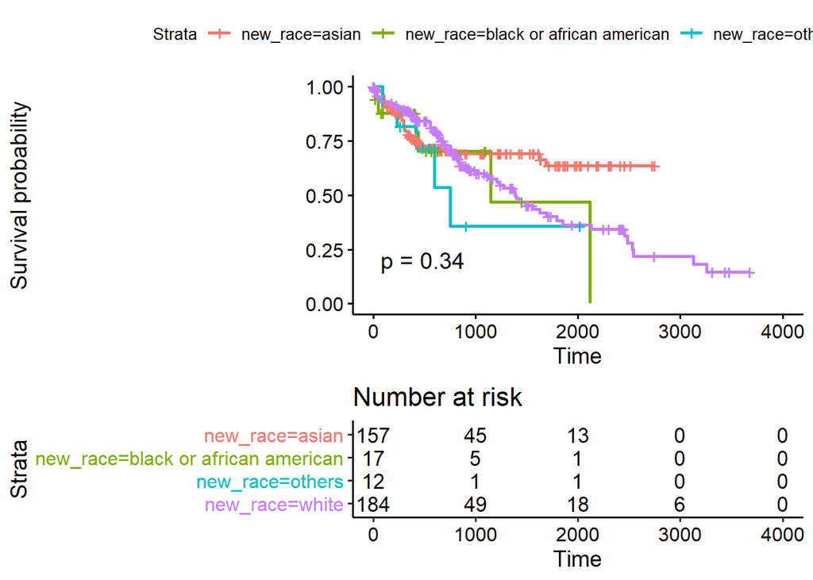

```r
# we produce a Kaplan-Meier plot from the fitted model
ggsurvplot(fit, data=clin_df, pval=T, risk.table=T, risk.table.height=0.35)
```

Null hypothesis: there is no difference between the race survival curves (i.e. the probability of an event occurring at any time point is the same for each population)

This gives a P value of 0.34 which indicates no significant difference between the population survival curves or there is no correlation between race and survival. So the null hypothesis is not rejected